# Google Data Analytics Capstone: Cyclistic

## **10.7f Peak Season PM Commutes**

## **Baseline Trip Duration (PM)**

```r
##PM Baseline
annual_workday_duration_pm <- trips_workday %>%
  filter(start_hour >= 16 & start_hour <= 19) %>%
  group_by(customer_type, bike_type) %>%
  summarize(mean_duration = mean(trip_length))
view(annual_workday_duration_pm)
```

## **10.7f Baseline Trip Duration (PM)**

#### Casual riders have a baseline trip duration of 21 minutes and 17 seconds (1277 seconds) on classic bikes and a baseline trip duration of 16 minutes and 46 seconds (1006 seconds) on electric bikes.

#### Casual electric rides are on average 21.22% shorter than casual classic bike rides.

#### Members have a baseline trip duration of 13 minutes and 15 seconds (795 seconds) on classic bikes, and a baseline trip duration of 12 minutes and 20 seconds (740 seconds) on electric bikes.

#### Member electric rides are on average 6.97% shorter than member classic bike rides.

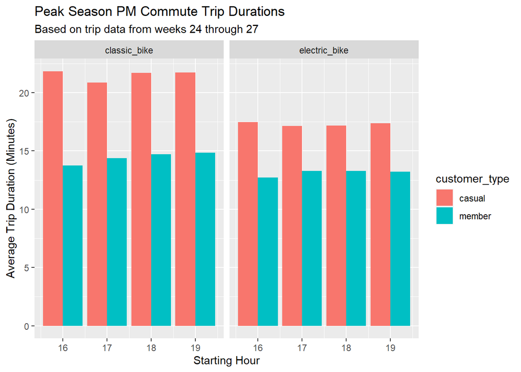

```r
viz_peak_season_workday_duration_pm <- ggplot(data =
                           peak_season_workday_grouped_pm_commute)+
  geom_col(mapping = aes(x = start_hour,
                         y = (mean_trip_duration/60),
                         fill = customer_type),
           position = 'dodge')+
  facet_wrap(~bike_type)+
  labs(title = "Peak Season PM Commute Trip Durations",
       subtitle = "Based on trip data from weeks 24 through 27",
       x = "Starting Hour",
       y = "Average Trip Duration (Minutes)")

print(viz_peak_season_workday_duration_pm)
```

## **10.7h Peak Season PM Commute Duration Findings**

#### A visualization of trip duration during the 4pm to 7:59pm commute window shows similar behavior for member riders as we saw during the AM commute: Shorter rides than casual riders, and very little variance in trip duration across bike types and starting hours.

#### Meanwhile, casual rider behavior appears to be much more consistent in the evening hours than we saw during the AM commute period, more closely reflecting member behavior patterns.

## **10.7g Inspecting PM Classic/Casual Trip Duration Variance**

```r
classic_casual_workday_pm_peak <- peak_season_workday %>%
  filter(customer_type == 'casual' & bike_type == 'classic_bike') %>%
  filter(start_hour >= 16 & start_hour <= 19) %>%
  group_by(start_hour) %>%
  summarize(mean_trip_duration = mean(trip_length)) %>%
  mutate(percent_variance = ((mean_trip_duration - 1277.1967)/1277.1967)*100)
```

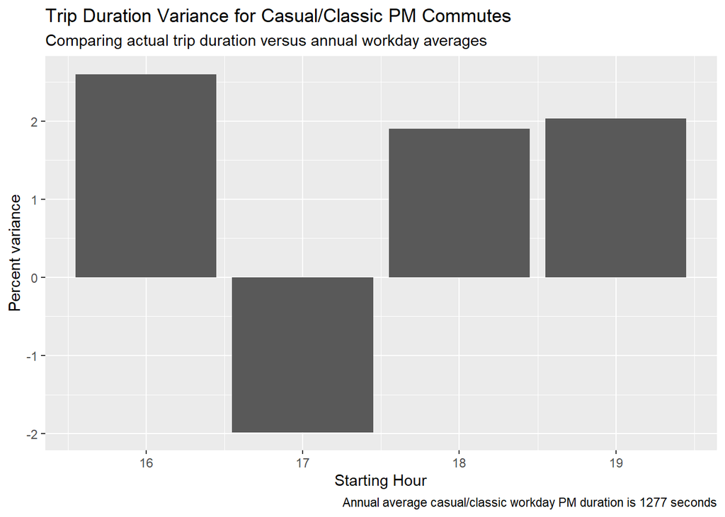

```r
viz_pm_casual_classic_variance <- ggplot(data = classic_casual_workday_pm_peak)+
  geom_col(mapping = aes(x = start_hour,
                         y = percent_variance)
  )+
  labs(title = 'Trip Duration Variance for Casual/Classic PM Commutes',
       subtitle = 'Comparing actual trip duration versus annual workday averages',
       x = 'Starting Hour',
       y = 'Percent variance',
       caption = 'Annual average casual/classic workday PM duration is 1277 seconds')

print(viz_pm_casual_classic_variance)
```

## **10.7g Inspecting PM Classic/Casual Trip Duration Variance**

#### The above visualization shows little variance in peak season classic/casual trip duration (-1.98% to 2.60%) compared to annual averages for the same time period.

## **10.7h Inspecting PM Electric/Casual Trip Duration Variance**

```r
electric_casual_workday_pm_peak <- peak_season_workday %>%
  filter(customer_type == 'casual' & bike_type == 'electric_bike') %>%
  filter(start_hour >= 16 & start_hour <= 19) %>%
  group_by(start_hour) %>%
  summarize(mean_trip_duration = mean(trip_length)) %>%
  mutate(percent_variance = ((mean_trip_duration - 1006.2264)/1006.2264)*100)
```

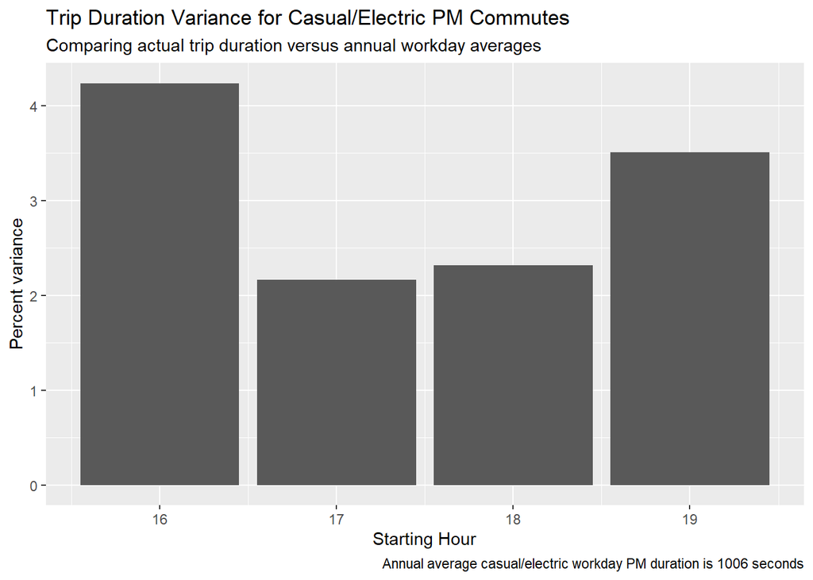

```r
viz_pm_casual_electric_variance <- ggplot(data = electric_casual_workday_pm_peak)+
  geom_col(mapping = aes(x = start_hour,
                         y = percent_variance)
  )+
  labs(title = 'Trip Duration Variance for Casual/Electric PM Commutes',
       subtitle = 'Comparing actual trip duration versus annual workday averages',
       x = 'Starting Hour',
       y = 'Percent variance',
       caption = 'Annual average casual/electric workday PM duration is 1006 seconds')

print(viz_pm_casual_electric_variance)
```

## **10.7h Inspecting PM Electric/Casual Trip Duration Variance**

#### The above visualization shows that casual riders on electric bikes are prone to slightly longer rides than the annual average for this time period, however this variance is marginal at between 2.16% and 4.24%.